# Peer Assessment 1-Reproducible Research

This is the Markdown file for Peer Assessment-1

### Load the data provided

This assignment makes use of data from a personal activity monitoring device. This device collects data at 5 minute intervals through out the day. The data consists of two months of data from an anonymous individual collected during the months of October and November, 2012 and include the number of steps taken in 5 minute intervals each day.

The variables included in this dataset are:

```
1. steps = Number of steps taking in a 5-minute interval (missing values are coded as NA)

2. date = The date on which the measurement was taken in YYYY-MM-DD format

3. interval: Identifier for the 5-minute interval in which measurement was taken
```

Code for loading data:

```r
rawdata= read.csv("activity.csv", header = TRUE)
```

## Q1 - What is mean total number of steps taken per day?

```r
library(dplyr)
```

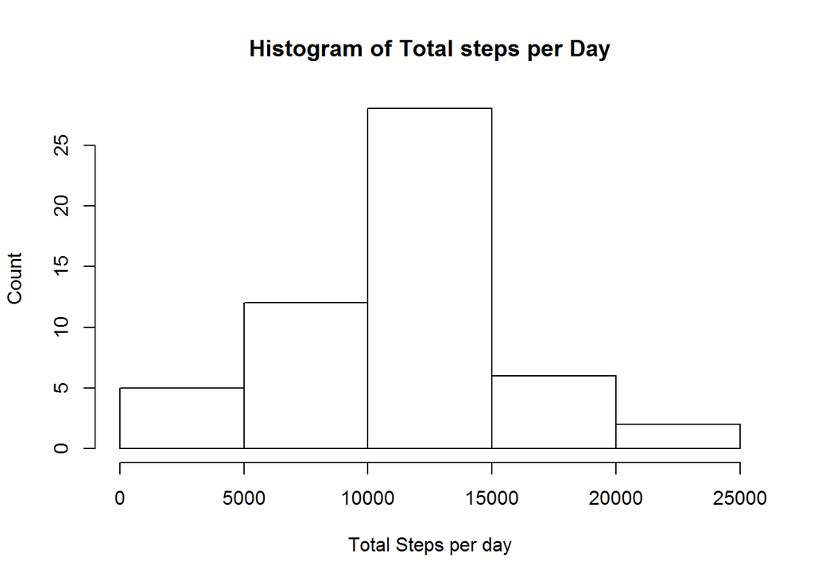

```r
comp_data = na.omit(rawdata)
comp_data$date <- as.Date(comp_data$date)
stepsperday <- comp_data %>%
  group_by(date)%>%
  summarize(totsteps = sum(steps))

hist(stepsperday$totsteps,xlab = "Total Steps per day", ylab = "Count", main = "Histogram of Total steps per Day")
```

```r
meanperday <- mean(stepsperday$totsteps)
medianperday <- median(stepsperday$totsteps)
```

## Q2 - What is average daily activity pattern?

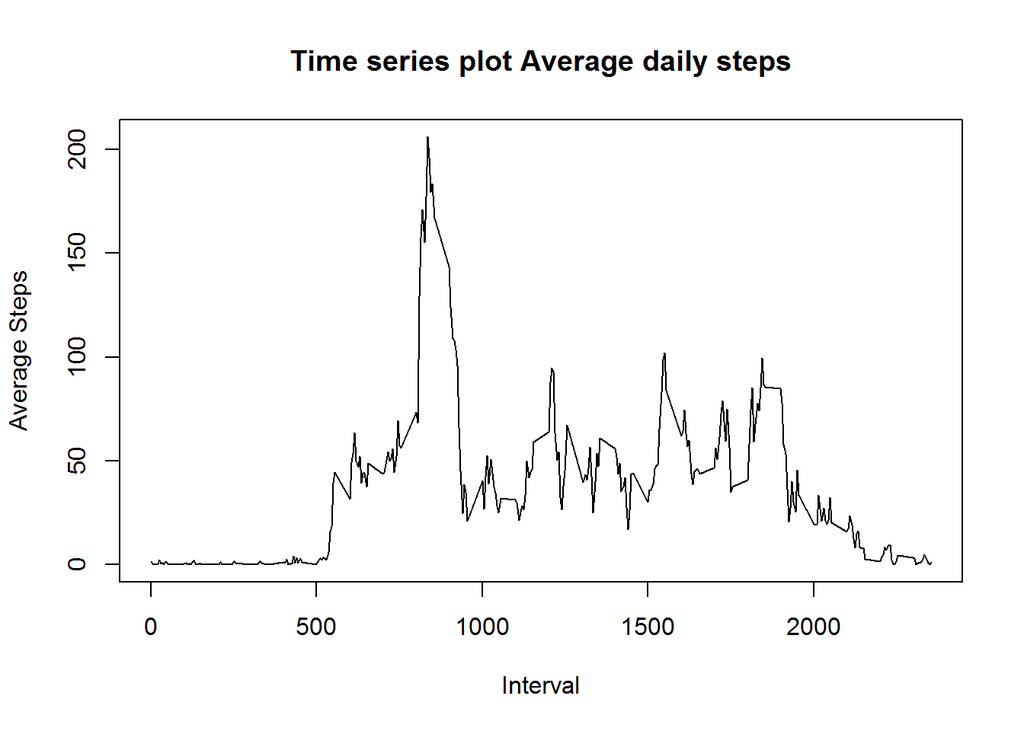

```r
library(dplyr)
avgsteps<- comp_data %>%
  group_by(interval)%>%
  summarize(avg = mean(steps))

plot(avgsteps$interval,avgsteps$avg,type="l", xlab = "Interval", ylab = "Average Steps", main = "Time series plot Average daily steps")
```

```r
maxsteps<-avgsteps$interval[which.max(avgsteps$avg)]
```

5 minute interval which has max number of steps is 835

## Q3 - Fill “NAs” using Average and plot Histogram of total Steps per day

```r
nadata <- rawdata
for (n in 1:nrow(nadata)){
  if (is.na(nadata$steps[n])){
    naindx <-which(nadata$interval[n]==avgsteps$interval)
    nadata$steps[n] <- avgsteps[naindx,]$avg
  }
}
nadata$date <-as.Date(nadata$date)
```

Histogram Plotting

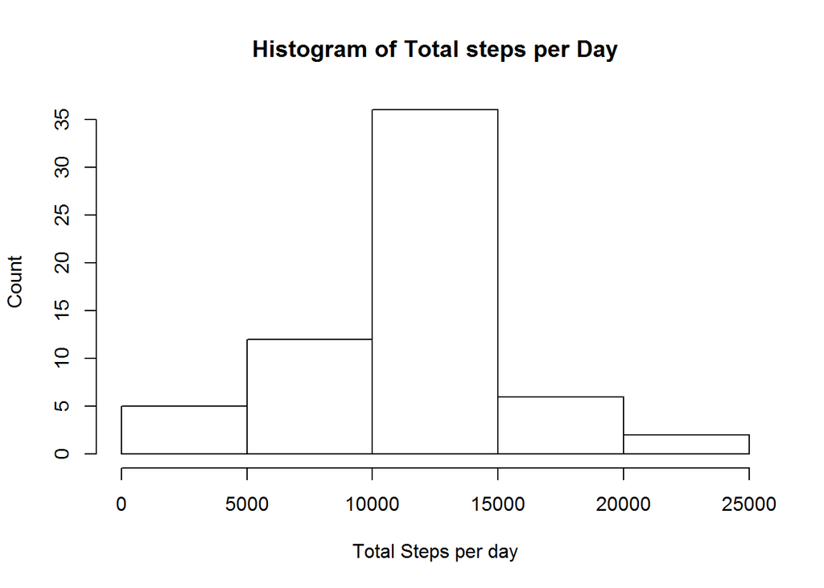

```r
stepsperday <- nadata %>%
  group_by(date)%>%
  summarize(totsteps = sum(steps))
hist(stepsperday$totsteps,xlab = "Total Steps per day", ylab = "Count", main = "Histogram of Total steps per Day")
```

```r
meanperday <- mean(stepsperday$totsteps)
medianperday <- median(stepsperday$totsteps)
```

## Q4 - Differences in Weekday and Weekend Pattern

```r
nadata$day <- weekdays(nadata$date)
nadata$daytyp <- "Weekday"
nadata$daytyp[nadata$day %in% c("Saturday","Sunday")] <- "Weekend"
average <- nadata %>%
  group_by(daytyp,interval) %>%
  summarize(avgsteps=mean(steps))
```

Create a Panel plot to compare the Weekday and Weekend trend

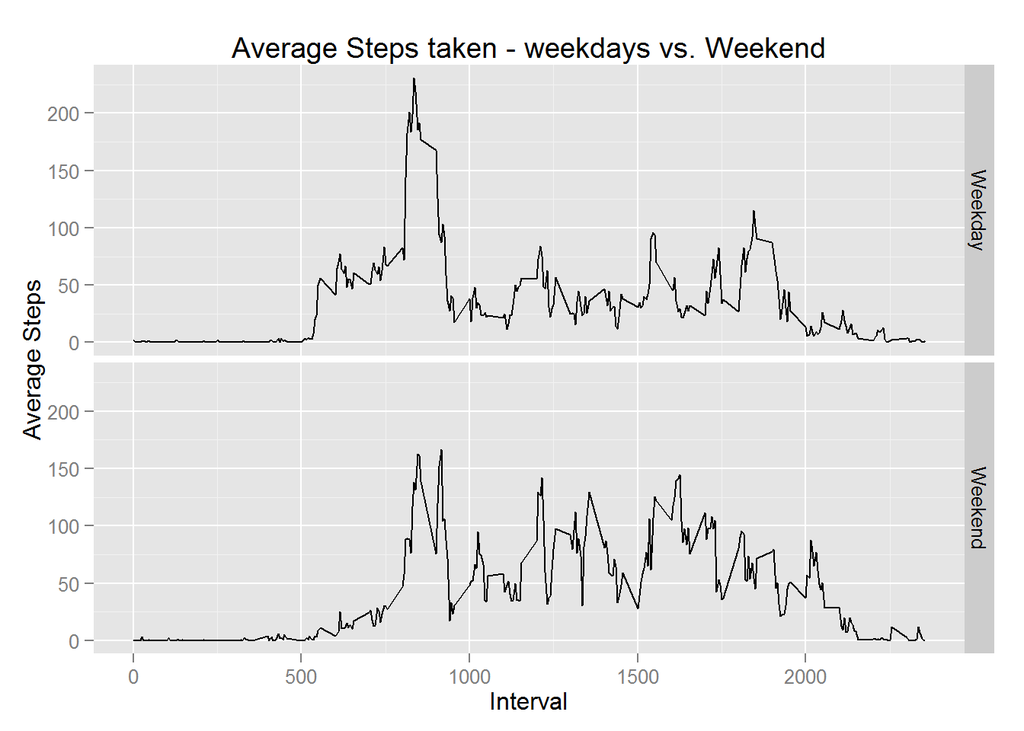

```r
library(ggplot2)
qplot(interval,avgsteps,data=average,geom="line",xlab = "Interval", ylab = "Average Steps", main = "Average Steps taken - weekdays vs. Weekend", facets=daytyp~.)
```

People seem to be more active after 1000 min during the weekends. Probably they are enjoying the weekend outside